# Peer Assessment I

First, let us load the data and necessary packages:

```r
load("ames_train.Rdata")
library(MASS)
library(dplyr)
library(ggplot2)
```

# 1

Make a labeled histogram (with 30 bins) of the ages of the houses in the data set, and describe the distribution.

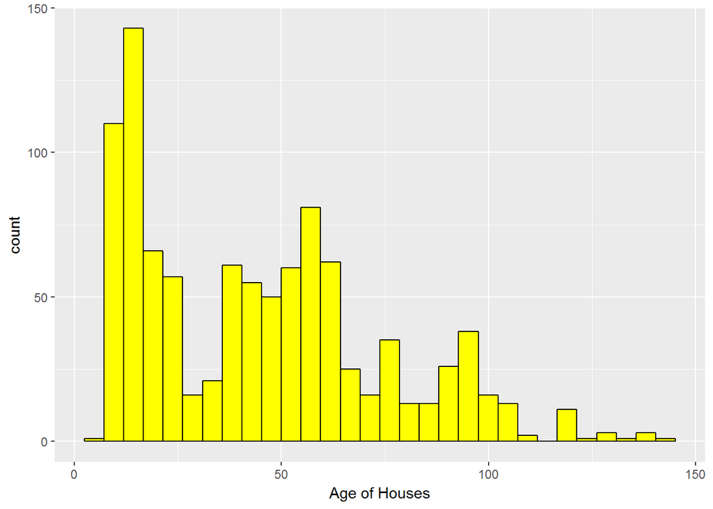

```r
ames_train <- ames_train %>%
  mutate(age = 2017-Year.Built)
ggplot(ames_train, aes(x=age))+ geom_histogram(fill="yellow", color="black", bins=30) + xlab("Age of Houses")
```

```r
summary(ames_train$age)
```

```
##    Min. 1st Qu.  Median    Mean 3rd Qu.    Max.
##     7.0    16.0    42.0    44.8    62.0   145.0
```

The distribution of age of houses is **right-skewed**, with a mean larger than median by 2.8. As the life span of houses are limited, there are less old houses, addtionally **a large amount of new houses were built**, which in combination acount for the skew. In addition, the data is **multimodal**.

# 2

The mantra in real estate is “Location, Location, Location!” Make a graphical display that relates a home price to its neighborhood in Ames, Iowa. Which summary statistics are most appropriate to use for determining the most expensive, least expensive, and most heterogeneous (having the most variation in housing price) neighborhoods? Report which neighborhoods these are based on the summary statistics of your choice. Report the value of your chosen summary statistics for these neighborhoods.

```r
price_neighbor <- ames_train %>%
  group_by(Neighborhood)
Orders <- price_neighbor %>%
  summarise(mean.price = mean(price), median.price = median(price), sd.price = sd(price))
(Orders %>%
  arrange(-mean.price))[1:5,]
```

```
## # A tibble: 5 x 4
##   Neighborhood mean.price median.price  sd.price
##         <fctr>      <dbl>        <dbl>     <dbl>
## 1      StoneBr   339316.0     340691.5 123459.10
## 2      NridgHt   333646.7     336860.0 105088.90
## 3      NoRidge   295844.6     290000.0  35888.97
## 4      GrnHill   280000.0     280000.0  70710.68
## 5       Timber   265192.2     232500.0  84029.57
```

```r
(Orders %>%
  arrange(mean.price))[1:5,]
```

```
## # A tibble: 5 x 4
##   Neighborhood mean.price median.price sd.price
##         <fctr>      <dbl>        <dbl>    <dbl>
## 1      MeadowV   92946.88        85750 18939.78
## 2       IDOTRR   97620.69        99500 31530.44
## 3       BrDale   98930.00        98750 13337.59
## 4      OldTown  120225.61       120000 36429.69
## 5      BrkSide  122472.56       124000 37309.91
```

```r
(Orders %>%
  arrange(-sd.price))[1:5,]
```

```
## # A tibble: 5 x 4
##   Neighborhood mean.price median.price  sd.price
##         <fctr>      <dbl>        <dbl>     <dbl>
## 1      StoneBr   339316.0     340691.5 123459.10
## 2      NridgHt   333646.7     336860.0 105088.90
## 3       Timber   265192.2     232500.0  84029.57
## 4      Veenker   233650.0     205750.0  72545.41
## 5      Crawfor   204196.6     205000.0  71267.56
```

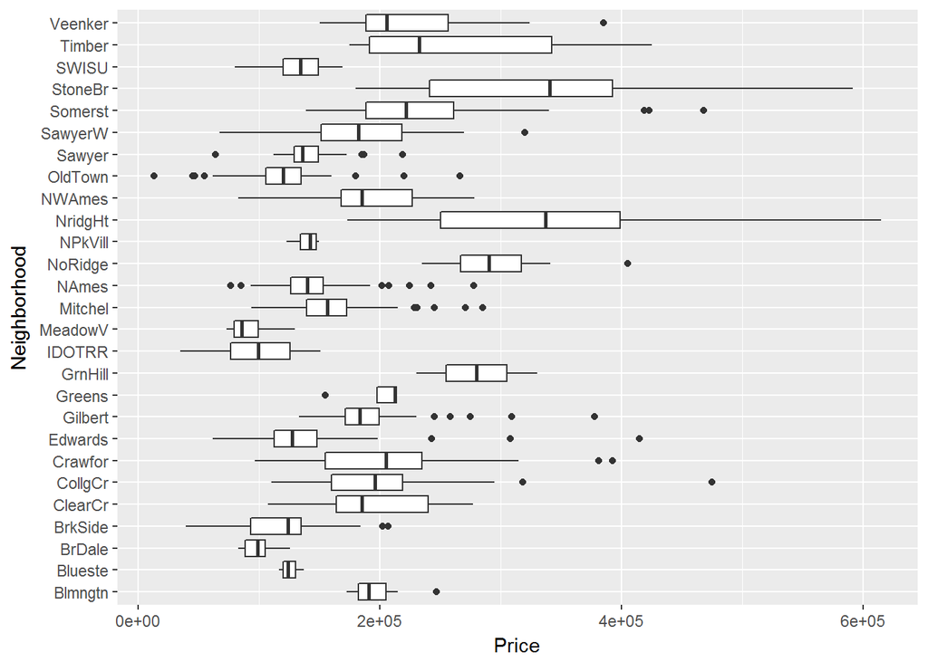

```r
ggplot(price_neighbor, aes(y=price, x=Neighborhood)) + geom_boxplot() + coord_flip()+ylab("Price")
```

**Median** is the correct summary statistic to determine the most and least expensive neighborhoods; and **standard deviation** is the correct summary statistic to determine the most heterogenous neighborhood.

The most expensive neighboorhood is Stone Brook, with a median sale price of 340691.50.

The least expensive neighboorhood is Meadow Village, with a median sale price of 85750.

The most heterogeneous neighborhood is Stone Brook, with a standard deviation of 123459.10.

# 3

Which variable has the largest number of missing values? Explain why it makes sense that there are so many missing values for this variable.

```r
na_count <-sapply(ames_train, function(y) sum(is.na(y)))
(na_count[order(-na_count)])[1:5]
```

```
##      Pool.QC Misc.Feature        Alley        Fence Fireplace.Qu
##          997          971          933          798          491
```

```r
ames_train %>%
  group_by(Pool.Area) %>%
  summarise(count=n())
```

```
## # A tibble: 4 x 2
##   Pool.Area count
##       <int> <int>
## 1         0   997
## 2       144     1
## 3       519     1
## 4       800     1
```

The variable `Pool.Qc` has the largest number of missing values. `Pool.QC` is intended to describe swimming pool quality, but most homes (997 out of 1000) do not have swimming pools. Therefore `"NA"` values show most frequently here.

# 4

We want to predict the natural log of the home prices. Candidate explanatory variables are lot size in square feet (Lot.Area), slope of property (Land.Slope), original construction date (Year.Built), remodel date (Year.Remod.Add), and the number of bedrooms above grade (Bedroom.AbvGr). Pick a model selection or model averaging method covered in the Specialization, and describe how this method works. Then, use this method to find the best multiple regression model for predicting the natural log of the home prices.

Let’s get started with a full model.

```r
ames_train <- ames_train %>%
  mutate (log.price=log(price))
m1<- lm(log.price~Lot.Area+Land.Slope+Year.Built+Year.Remod.Add+Bedroom.AbvGr, data=ames_train)
step1 <- stepAIC(m1, direction="both", k=2)
```

```
## Start:  AIC=-2545.77
## log.price ~ Lot.Area + Land.Slope + Year.Built + Year.Remod.Add +
##     Bedroom.AbvGr
##
##                  Df Sum of Sq    RSS     AIC
## <none>                        77.322 -2545.8
## - Land.Slope      2    1.4281 78.750 -2531.5
## - Bedroom.AbvGr   1    5.0628 82.385 -2484.3
## - Lot.Area        1    6.7292 84.051 -2464.3
## - Year.Remod.Add  1   11.9642 89.286 -2403.9
## - Year.Built      1   19.8546 97.177 -2319.2
```

```r
summary(step1)
```

```
##
## Call:
## lm(formula = log.price ~ Lot.Area + Land.Slope + Year.Built +
##     Year.Remod.Add + Bedroom.AbvGr, data = ames_train)
##
## Residuals:
##     Min      1Q  Median      3Q     Max
## -2.0878 -0.1651 -0.0211  0.1657  0.9945
##
## Coefficients:
##                  Estimate Std. Error t value Pr(>|t|)
## (Intercept)    -1.371e+01  8.574e-01 -15.996  < 2e-16 ***
## Lot.Area        1.028e-05  1.106e-06   9.296  < 2e-16 ***
## Land.SlopeMod   1.384e-01  4.991e-02   2.773  0.00565 **
## Land.SlopeSev  -4.567e-01  1.514e-01  -3.016  0.00263 **
## Year.Built      6.049e-03  3.788e-04  15.968  < 2e-16 ***
## Year.Remod.Add  6.778e-03  5.468e-04  12.395  < 2e-16 ***
## Bedroom.AbvGr   8.686e-02  1.077e-02   8.063 2.12e-15 ***
## ---
## Signif. codes:  0 '***' 0.001 '**' 0.01 '*' 0.05 '.' 0.1 ' ' 1
##
## Residual standard error: 0.279 on 993 degrees of freedom
## Multiple R-squared:  0.5625, Adjusted R-squared:  0.5598
## F-statistic: 212.8 on 6 and 993 DF,  p-value: < 2.2e-16
```

From the report of stepwise model selection by AIC approach above, **we can find that full model remains to be the best fit.**

BIC is an estimate of a function of the posterior probability of a model being true, under a certain Bayesian setup. **The lower AIC and (or) BIC, the better.**

**AIC is better in situations when a false negative finding would be considered more misleading than a false positive;** while BIC is better in situations where a false positive is more misleading than a false negative.

Since penalties for false positive and false negative are the same in our model, **we could select the AIC method**.

**By AIC method, we find that full model fits our needs best.**

# 5

Which home has the largest squared residual in the previous analysis (Question 4)? Looking at all the variables in the data set, can you explain why this home stands out from the rest (what factors contribute to the high squared residual and why are those factors relevant)?

```r
summary(m1$residuals)
```

```
##    Min. 1st Qu.  Median    Mean 3rd Qu.    Max.
## -2.0879 -0.1651 -0.0211  0.0000  0.1657  0.9945
```

```r
m1$resids_square <- (m1$residuals)^2
max_resid <- which(m1$resids_square==max(m1$resids_square))
max_resid
```

```
## 428
## 428
```

Review observation 428 in particular.

```r
Q5 <- data.frame(ames_train)
Q5[max_resid,]
```

```
##           PID area price MS.SubClass MS.Zoning Lot.Frontage Lot.Area
## 428 902207130  832 12789          30        RM           68     9656
##     Street Alley Lot.Shape Land.Contour Utilities Lot.Config Land.Slope
## 428   Pave  <NA>       Reg          Lvl    AllPub     Inside        Gtl
##     Neighborhood Condition.1 Condition.2 Bldg.Type House.Style
## 428      OldTown        Norm        Norm      1Fam      1Story
##     Overall.Qual Overall.Cond Year.Built Year.Remod.Add Roof.Style
## 428            2            2       1923           1970      Gable
##     Roof.Matl Exterior.1st Exterior.2nd Mas.Vnr.Type Mas.Vnr.Area
## 428   CompShg      AsbShng      AsbShng         None            0
##     Exter.Qual Exter.Cond Foundation Bsmt.Qual Bsmt.Cond Bsmt.Exposure
## 428         TA         Fa     BrkTil        Fa        Fa            No
##     BsmtFin.Type.1 BsmtFin.SF.1 BsmtFin.Type.2 BsmtFin.SF.2 Bsmt.Unf.SF
## 428            Unf            0            Unf            0         678
##     Total.Bsmt.SF Heating Heating.QC Central.Air Electrical X1st.Flr.SF
## 428           678    GasA         TA           N      SBrkr         832
##     X2nd.Flr.SF Low.Qual.Fin.SF Bsmt.Full.Bath Bsmt.Half.Bath Full.Bath
## 428           0               0              0              0         1
##     Half.Bath Bedroom.AbvGr Kitchen.AbvGr Kitchen.Qual TotRms.AbvGrd
## 428         0             2             1           TA             5
##     Functional Fireplaces Fireplace.Qu Garage.Type Garage.Yr.Blt
## 428        Typ          1           Gd      Detchd          1928
##     Garage.Finish Garage.Cars Garage.Area Garage.Qual Garage.Cond
## 428           Unf           2         780          Fa          Fa
##     Paved.Drive Wood.Deck.SF Open.Porch.SF Enclosed.Porch X3Ssn.Porch
## 428           N            0             0              0           0
##     Screen.Porch Pool.Area Pool.QC Fence Misc.Feature Misc.Val Mo.Sold
## 428            0         0    <NA>  <NA>         <NA>        0       6
##     Yr.Sold Sale.Type Sale.Condition age log.price
## 428    2010       WD         Abnorml  94  9.456341
```

**The observation coded 428 has the largest squared residual.**

**From the review report above, observation 428 were sold for a very low price given the considerable lot size and two bedrooms. The reason might be its age.**

# 6

Use the same model selection method you chose in Question 4 to again find the best multiple regression model to predict the natural log of home prices, but this time **replacing Lot.Area with log(Lot.Area)**. Do you arrive at a model including the same set of predictors?

Start with full model, and conduct a stepwise process of model selection by AIC approach.

```r
m2<- lm( log.price ~ log(Lot.Area) + Land.Slope + Year.Built + Year.Remod.Add + Bedroom.AbvGr, data=ames_train)
step2 <- stepAIC(m2, direction="both", k=2)
```

```
## Start:  AIC=-2649.5
## log.price ~ log(Lot.Area) + Land.Slope + Year.Built + Year.Remod.Add +
##     Bedroom.AbvGr
##
##                  Df Sum of Sq    RSS     AIC
## <none>                        69.704 -2649.5
## - Land.Slope      2    0.4429 70.147 -2647.2
## - Bedroom.AbvGr   1    2.2002 71.904 -2620.4
## - Year.Remod.Add  1   11.8182 81.522 -2494.9
## - log(Lot.Area)   1   14.3474 84.051 -2464.3
## - Year.Built      1   19.4083 89.112 -2405.9
```

```r
summary(step2)
```

```
##
## Call:
## lm(formula = log.price ~ log(Lot.Area) + Land.Slope + Year.Built +
##     Year.Remod.Add + Bedroom.AbvGr, data = ames_train)
##
## Residuals:
##      Min       1Q   Median       3Q      Max
## -2.14050 -0.15650 -0.01561  0.15350  0.90854
##
## Coefficients:
##                  Estimate Std. Error t value Pr(>|t|)
## (Intercept)    -1.553e+01  8.197e-01 -18.947  < 2e-16 ***
## log(Lot.Area)   2.442e-01  1.708e-02  14.297  < 2e-16 ***
## Land.SlopeMod   1.151e-01  4.734e-02   2.431   0.0152 *
## Land.SlopeSev  -6.554e-02  1.222e-01  -0.536   0.5917
## Year.Built      5.981e-03  3.597e-04  16.628  < 2e-16 ***
## Year.Remod.Add  6.734e-03  5.190e-04  12.975  < 2e-16 ***
## Bedroom.AbvGr   5.909e-02  1.055e-02   5.599  2.8e-08 ***
## ---
## Signif. codes:  0 '***' 0.001 '**' 0.01 '*' 0.05 '.' 0.1 ' ' 1
##
## Residual standard error: 0.2649 on 993 degrees of freedom
## Multiple R-squared:  0.6056, Adjusted R-squared:  0.6032
## F-statistic: 254.1 on 6 and 993 DF,  p-value: < 2.2e-16
```

From the report above, **we know that full model remains to be the best fit, even we convert `Lot.Area` to log-scale.**

# 7

Do you think it is better to log transform Lot.Area, in terms of assumptions for linear regression? Make graphs of the predicted values of log home price versus the true values of log home price for the regression models selected for Lot.Area and log(Lot.Area). Referencing these two plots, provide a written support that includes a quantitative justification for your answer in the first part of question 7.

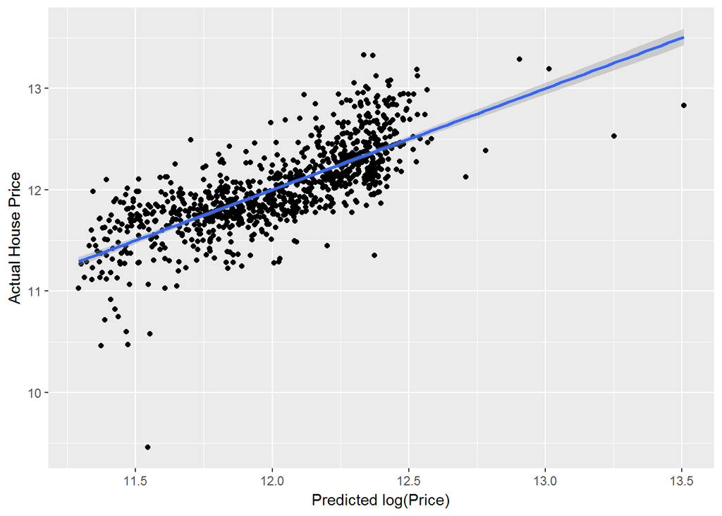

```r
ggplot(data = m1, aes(x = .fitted, y =log.price)) +
  geom_point() +
  geom_smooth(method=lm, se=TRUE) +
  xlab("Predicted log(Price)") + ylab("Actual House Price")
```

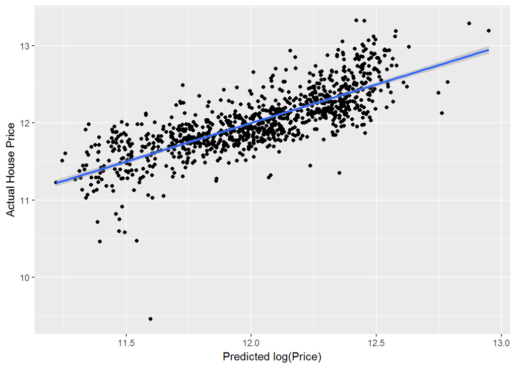

```r
ggplot(data = m2, aes(x = .fitted, y =log.price)) +
  geom_point() +
  geom_smooth(method=lm, se=TRUE) +
  xlab("Predicted log(Price)") + ylab("Actual House Price")
```

Although full model remains the best fit, which is the same for question 4 and question 6, **converting `Lot.Area` to log-scale still enhances the model, as R-squared increases, and the variance of residuals reduces.** These conclusions are based on the plots above and the summary of the two models.